# 05-serological_classification

2023-04-16

# packages

```r
library(tidyverse)
library(mixtools)
library(patchwork)
library(conflicted)
conflicts_prefer(dplyr::select)
conflicts_prefer(dplyr::filter)
```

```r
options(scipen=10000)
```

# import input data

```r
data_output_03 <- read_rds("data/03-data-ab_units-complete.rds")
```

## extract antibody units estimates

```r
data_output_03_abunit <- data_output_03 %>%
  dplyr::select(plate,experimento,estimation) %>%
  unnest(cols = estimation) %>%

  # extra code to create unique id
  mutate(unique_id = paste0(#experimento,"-",
                            plate,"--",codigo))
```

```r
data_output_03_abunit %>% rmarkdown::paged_table()
```

| plate | experimento | rowname | codigo | densidad_replicate | densidad_mean | densidad_sd | densidad_cv | estimate | std_error | lower | upper | unique_id |
| --- | --- | --- | --- | --- | --- | --- | --- | --- | --- | --- | --- | --- |
| placa_001 | igg | 1 | NSH-3001 | 2 | 0.70500000 | 0.0183847763 | 2.6077697 | 48.89389984 | 27.93188807 | -15.517149550 | 113.30494923 | placa_001--NSH-3001 |
| placa_001 | igg | 2 | NSH-3002 | 2 | 1.20450000 | 0.1393000359 | 11.5649677 | 883.23577457 | 1020.43954602 | -1469.902038267 | 3236.37358741 | placa_001--NSH-3002 |
| placa_001 | igg | 3 | NSH-3003 | 2 | 0.88650000 | 0.1449568901 | 16.3515951 | 129.51736790 | 98.63019477 | -97.924269100 | 356.95900491 | placa_001--NSH-3003 |
| placa_001 | igg | 4 | NSH-3004 | 2 | 0.32350000 | 0.0077781746 | 2.4043816 | 4.96195369 | 1.34701916 | 1.855721940 | 8.06818545 | placa_001--NSH-3004 |
| placa_001 | igg | 5 | NSH-3005 | 2 | 0.98000000 | 0.0848528137 | 8.6584504 | 217.42472141 | 188.32812015 | -216.860702442 | 651.71014526 | placa_001--NSH-3005 |
| placa_001 | igg | 6 | NSH-3006 | 2 | 0.36450000 | 0.0063639610 | 1.7459427 | 6.61823840 | 1.86070332 | 2.327448854 | 10.90902794 | placa_001--NSH-3006 |
| placa_001 | igg | 7 | NSH-3007 | 2 | 0.52600000 | 0.0042426407 | 0.8065857 | 18.13343395 | 7.20253602 | 1.524356091 | 34.74251180 | placa_001--NSH-3007 |
| placa_001 | igg | 8 | NSH-3008 | 2 | 0.55500000 | 0.0296984848 | 5.3510783 | 21.42041217 | 9.08194667 | 0.477405595 | 42.36341874 | placa_001--NSH-3008 |
| placa_001 | igg | 9 | NSH-3009 | 2 | 0.24350000 | 0.0247487373 | 10.1637525 | 2.66226985 | 0.79056538 | 0.839222821 | 4.48531688 | placa_001--NSH-3009 |
| placa_001 | igg | 10 | NSH-3010 | 2 | 0.68600000 | 0.1202081528 | 17.5230543 | 44.13948546 | 24.36834824 | -12.054026350 | 100.33299728 | placa_001--NSH-3010 |

[output cut: 240 more lines]

## reminder

observations are unique when stratified by `experimento` and combined by `plate`, `codigo`:

```r
data_output_03_abunit %>%
  filter(str_detect(codigo,"ctrl_")) %>%
  filter(magrittr::is_in(plate,c("placa_001","placa_002"))) %>%
  select(experimento,unique_id) %>%
  arrange(experimento)
```

```
## # A tibble: 12 × 2
##    experimento unique_id
##    <chr>       <chr>
##  1 igg         placa_001--ctrl_blanco
##  2 igg         placa_001--ctrl_negativo
##  3 igg         placa_001--ctrl_positivo
##  4 igg         placa_002--ctrl_blanco
##  5 igg         placa_002--ctrl_negativo
##  6 igg         placa_002--ctrl_positivo
##  7 igg-avidez  placa_001--ctrl_blanco
##  8 igg-avidez  placa_001--ctrl_negativo
##  9 igg-avidez  placa_001--ctrl_positivo
## 10 igg-avidez  placa_002--ctrl_blanco
## 11 igg-avidez  placa_002--ctrl_negativo
## 12 igg-avidez  placa_002--ctrl_positivo
```

# explore data

## antibody distribution in sample

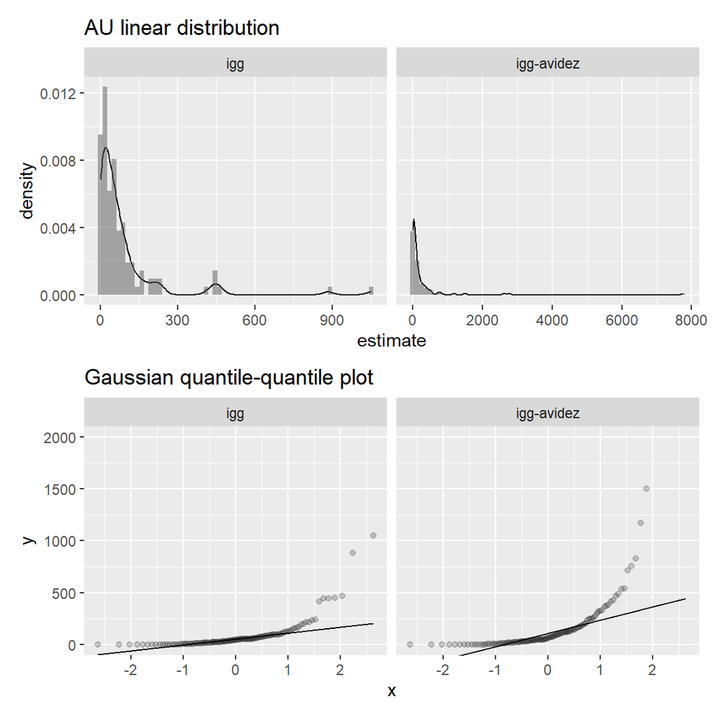

```r
fig01_a <- data_output_03_abunit %>%
  ggplot(aes(x = estimate)) +
  geom_density(alpha=.5,
               position = "identity") +
  geom_histogram(aes(y = after_stat(density)),
                 bins = 60,
                 alpha=.5,
                 position = "identity") +
  facet_grid(~experimento,scales = "free") +
  #theme(axis.text.x = element_text(angle = 45, hjust = 1)) +
  labs(title="AU linear distribution")

fig01_b <- data_output_03_abunit %>%
  ggplot(aes(sample = estimate)) +
  geom_qq(alpha=.2) +
  geom_qq_line(line.p = c(0.25, 0.75)) +
  facet_grid(~experimento,scales = "free") +
  labs(title="Gaussian quantile-quantile plot") +
  coord_cartesian(ylim = c(0,2000))

fig01_a / fig01_b
```

## identify missing values

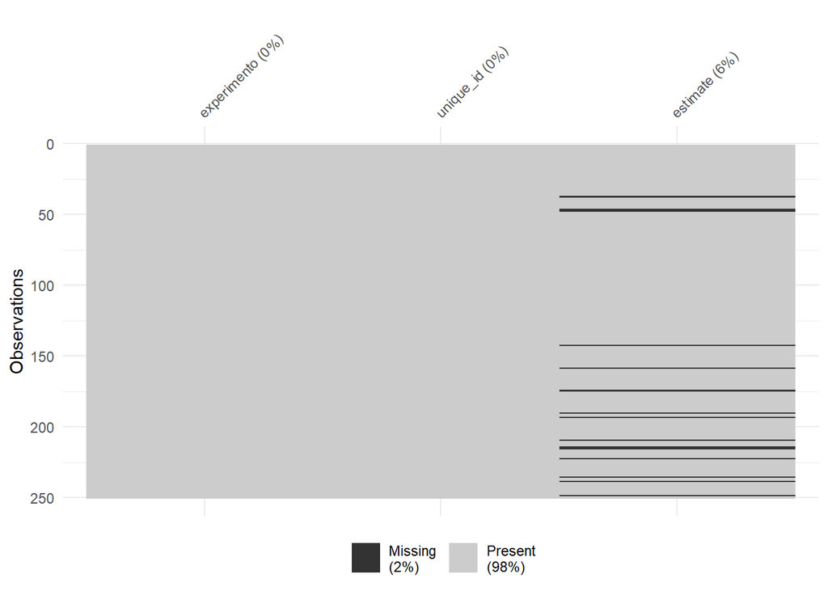

```r
data_output_03_abunit %>%
  select(experimento,unique_id,estimate) %>%
  naniar::vis_miss()
```

# fit a gaussian mixture model

Use `mixtools` package following the blog post about [Using Mixture Models for Clustering](https://tinyheero.github.io/2015/10/13/mixture-model.html)

Use it for two `experimento` and at least two `k-component` variations `k=2` and `k=3`

## for one strata

```r
data_output_03_abunit %>%
  select(experimento,estimate) %>%
  filter(!is.na(estimate)) %>%
  filter(experimento=="igg") %>%
  pull(estimate) %>%
  normalmixEM(k=2) %>%
  class()
```

```
## number of iterations= 19
```

```
## [1] "mixEM"
```

## for all stratas and all components

```r
model_output_01 <- data_output_03_abunit %>%
  # filter(experimento=="igg") %>%
  select(experimento,unique_id,densidad_replicate,densidad_mean,densidad_sd,estimate) %>%
  # ojo: lost of sample of density values with missing estimates
  filter(!is.na(estimate)) %>%
  group_by(experimento) %>%
  nest() %>%
  ungroup() %>%
  mutate(estimate_strata = map(data,pull,estimate)) %>%
  # expand the grid by the combination of k components
  expand_grid(component_n = 2:5) %>%
  mutate(mixture_model =
           pmap(.l =
                  select(
                    .,
                    x = estimate_strata,
                    k = component_n
                  ),
                .f = normalmixEM)) %>%
  # extract the log likelihood
  mutate(loglikelihood = map_dbl(mixture_model,pluck,"loglik")) %>%
  # compute the aic
  mutate(aic=2*component_n-2*loglikelihood) %>%
  group_by(experimento) %>%
  mutate(aic_difference = aic - dplyr::lag(aic)) %>%
  ungroup()
```

```
## number of iterations= 24
## number of iterations= 67
## number of iterations= 79
## number of iterations= 153
## number of iterations= 124
## number of iterations= 39
## number of iterations= 27
## number of iterations= 62
```

```r
# model_output_01
```

## criteria for model selection

criteria to choose the number of `k-compartments` for a distribution:

- not based only on AIC criteria, but also in visual inspection of the distribution
- minimize the number of undetermined samples (`s0`)
- closer resemblance to the expected number of positives

## summary of model performance

```r
model_output_01 %>%
  select(experimento,component_n,loglikelihood,aic,aic_difference)
```

```
## # A tibble: 8 × 5
##   experimento component_n loglikelihood   aic aic_difference
##   <chr>             <int>         <dbl> <dbl>          <dbl>
## 1 igg                   2         -666. 1337.           NA
## 2 igg                   3         -653. 1313.          -24.1
## 3 igg                   4         -643. 1293.          -19.3
## 4 igg                   5         -626. 1262.          -31.0
## 5 igg-avidez            2         -783. 1570.           NA
## 6 igg-avidez            3         -741. 1488.          -82.4
## 7 igg-avidez            4         -721. 1450.          -37.5
## 8 igg-avidez            5         -709. 1429.          -21.6
```

## visualize mixture model performance

### function to plot mixture components

```r
#' Plot a Mixture Component
#'
#' @param x Input data
#' @param mu Mean of component
#' @param sigma Standard deviation of component
#' @param lam Mixture weight of component
plot_mix_comps <- function(x, mu, sigma, lam) {
  lam * dnorm(x, mu, sigma)
}

stat_mixture <- function(model_name, k_component, colour) {
  stat_function(geom = "line", fun = plot_mix_comps,
                args = list(model_name$mu[k_component],
                            model_name$sigma[k_component],
                            lam = model_name$lambda[k_component]),
                colour = colour, lwd = 1.5)
}
```

components distributions equivalent to multiple latent seropositive states:

| component | color | state |
| --- | --- | --- |
| comp.1 | red | s- |
| comp.2 | blue | s+ |
| comp.3 | green | s++ |

### experiment 1

```r
model_igg_k2 <- model_output_01 %>%
  filter(experimento == "igg",
         component_n == 2) %>%
  pull(mixture_model) %>%
  pluck(1)

fig02a <- data.frame(x = model_igg_k2$x) %>%
  ggplot() +
  geom_histogram(aes(x, after_stat(density)),
                 bins = 30,
                 alpha=.5,
                 position = "identity") +
  stat_mixture(model_name = model_igg_k2,k_component = 1,colour = "red") +
  stat_mixture(model_name = model_igg_k2,k_component = 2,colour = "blue")
```

```r
model_igg_k3 <- model_output_01 %>%
  filter(experimento == "igg",
         component_n == 3) %>%
  pull(mixture_model) %>%
  pluck(1)

fig02b <- data.frame(x = model_igg_k3$x) %>%
  ggplot() +
  geom_histogram(aes(x, after_stat(density)),
                 bins = 30,
                 alpha=.5,
                 position = "identity") +
  stat_mixture(model_name = model_igg_k3,k_component = 1,colour = "red") +
  stat_mixture(model_name = model_igg_k3,k_component = 2,colour = "blue") +
  stat_mixture(model_name = model_igg_k3,k_component = 3,colour = "green")
```

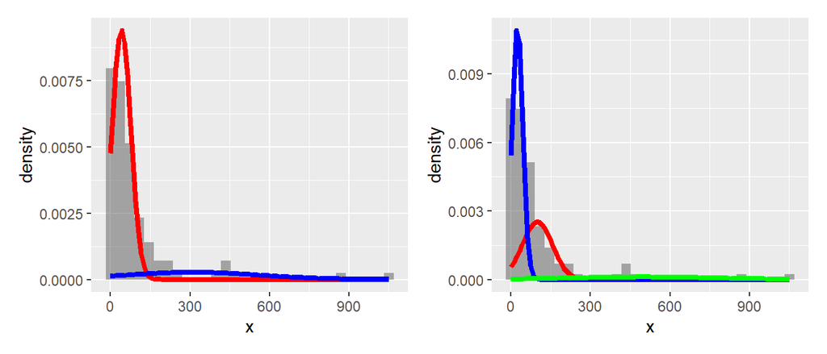

```r
fig02a + fig02b
```

### experiment 2

```r
model_avi_k2 <- model_output_01 %>%
  filter(experimento == "igg-avidez",
         component_n == 2) %>%
  pull(mixture_model) %>%
  pluck(1)

fig03a <- data.frame(x = model_avi_k2$x) %>%
  ggplot() +
  geom_histogram(aes(x, after_stat(density)),
                 bins = 30,
                 alpha=.5,
                 position = "identity") +
  stat_mixture(model_name = model_avi_k2,k_component = 1,colour = "red") +
  stat_mixture(model_name = model_avi_k2,k_component = 2,colour = "blue")
```

```r
model_avi_k3 <- model_output_01 %>%
  filter(experimento == "igg-avidez",
         component_n == 3) %>%
  pull(mixture_model) %>%
  pluck(1)

fig03b <- data.frame(x = model_avi_k3$x) %>%
  ggplot() +
  geom_histogram(aes(x, after_stat(density)),
                 bins = 30,
                 alpha=.5,
                 position = "identity") +
  stat_mixture(model_name = model_avi_k3,k_component = 1,colour = "red") +
  stat_mixture(model_name = model_avi_k3,k_component = 2,colour = "blue") +
  stat_mixture(model_name = model_avi_k3,k_component = 3,colour = "green")
```

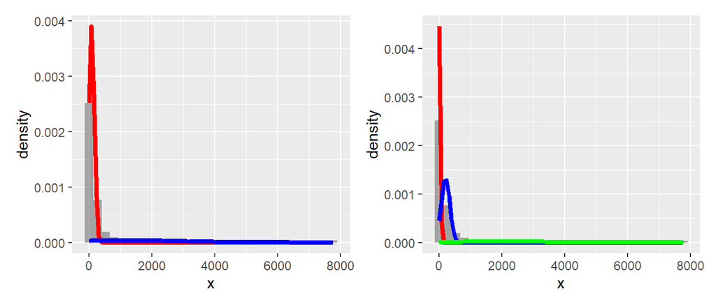

```r
fig03a + fig03b
```

# classify seropositivity

## define probability threshold

```r
class_probability <- 0.90
```

## classify using threshhold

```r
data_output_04 <- model_output_01 %>%
  filter(magrittr::is_in(component_n,c(2,3))) %>%
  select(experimento,data,component_n,mixture_model) %>%
  mutate(mixture_components = map(
    .x = mixture_model,
    .f = pluck, "posterior")) %>%
  mutate(mixture_components = map(
    .x = mixture_components,
    .f = as_tibble)) %>%
  select(-mixture_model) %>%
  unnest(cols = c(data,component_n,mixture_components)) %>%
  # for a clear number output
  # mutate(across(.cols = where(is.numeric),.fns = round, 8)) %>%
  mutate(across(.cols = where(is.numeric),.fns = \(x) round(x,8))) %>%
  # rmarkdown::paged_table()
  # # quality control
  # count(experimento,component_n)
  # rowwise to securily sum numbers removing missing values
  rowwise() %>%
  mutate(comp.23 = sum(c_across(cols = c(comp.2,comp.3)),na.rm = T)) %>%
  ungroup() %>%
  # k-labeling
  # two alternatives open to identify a superinfection latent class
  mutate(class = case_when(
    comp.1 > class_probability ~ "s-",
    comp.2 > class_probability ~ "s+",
    comp.3 > class_probability ~ "s++",
    TRUE ~ "s0"
  )) %>%
  mutate(class_sum = case_when(
    comp.1 > class_probability ~ "s-",
    comp.23 > class_probability ~ "s+",
    TRUE ~ "s0"
  )) %>%
  mutate(class = fct_relevel(class, "s-","s0","s+","s++")) %>%
  mutate(class_sum = fct_relevel(class_sum, "s-","s0","s+")) %>%
  # separate the unique id in case useful for user
  separate(col = unique_id,into = c("plate","codigo"),sep = "--",remove = F) %>%
  # send unique to the end
  relocate(unique_id, .after = last_col())
```

```r
data_output_04 #%>% rmarkdown::paged_table()
```

## summary of classification

```r
data_output_04 %>%
  count(experimento,component_n,class)
```

```
## # A tibble: 14 × 4
##    experimento component_n class     n
##    <chr>             <dbl> <fct> <int>
##  1 igg                   2 s-       96
##  2 igg                   2 s0        8
##  3 igg                   2 s+       14
##  4 igg                   3 s-       23
##  5 igg                   3 s0       39
##  6 igg                   3 s+       49
##  7 igg                   3 s++       7
##  8 igg-avidez            2 s-       95
##  9 igg-avidez            2 s0        8
## 10 igg-avidez            2 s+       14
## 11 igg-avidez            3 s-       45
## 12 igg-avidez            3 s0       22
## 13 igg-avidez            3 s+       42
## 14 igg-avidez            3 s++       8
```

```r
data_output_04 %>%
  count(experimento,component_n,class_sum)
```

```
## # A tibble: 12 × 4
##    experimento component_n class_sum     n
##    <chr>             <dbl> <fct>     <int>
##  1 igg                   2 s-           96
##  2 igg                   2 s0            8
##  3 igg                   2 s+           14
##  4 igg                   3 s-           23
##  5 igg                   3 s0           38
##  6 igg                   3 s+           57
##  7 igg-avidez            2 s-           95
##  8 igg-avidez            2 s0            8
##  9 igg-avidez            2 s+           14
## 10 igg-avidez            3 s-           45
## 11 igg-avidez            3 s0           20
## 12 igg-avidez            3 s+           52
```

## visualize classification

### by distribution

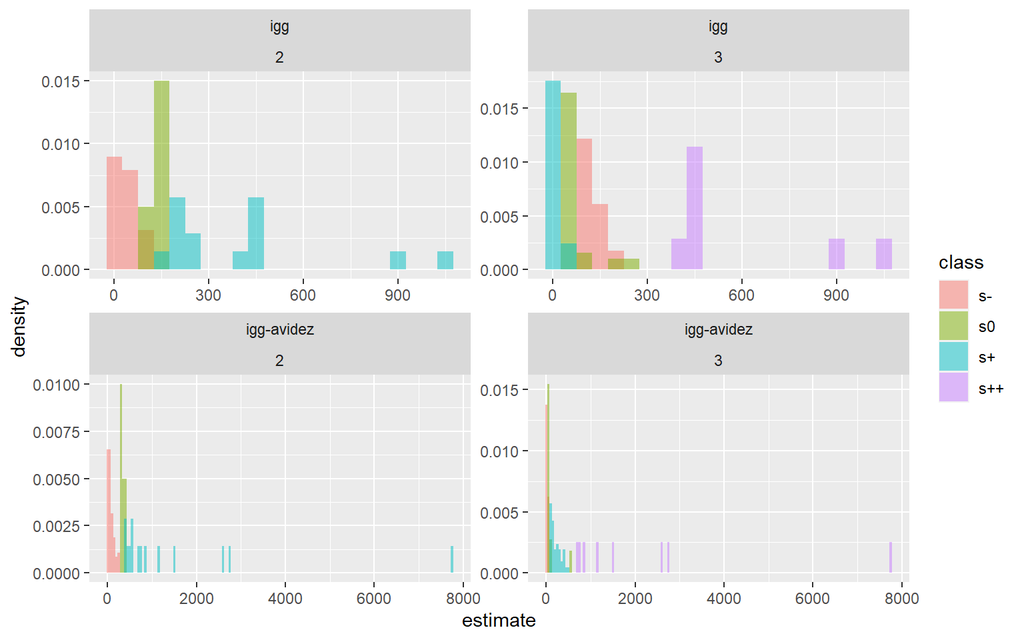

```r
data_output_04 %>%
  ggplot(aes(x = estimate,
             fill = class,
             after_stat(density))) +
  geom_histogram(binwidth = 50,
                 alpha=.5,
                 position = "identity") +
  facet_wrap(~experimento+component_n,scales = "free")
```

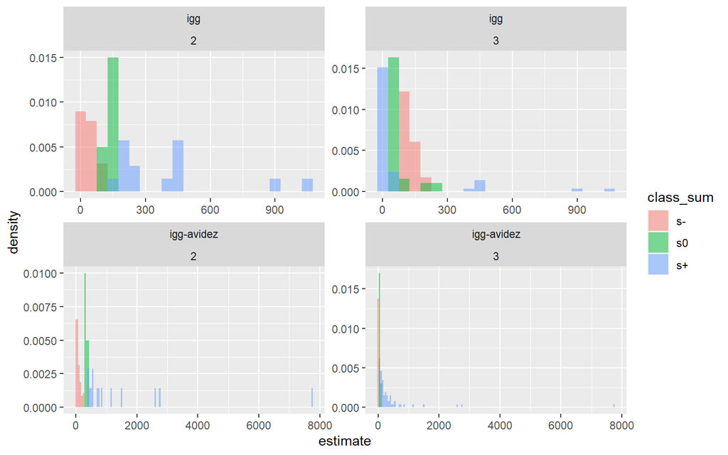

```r
data_output_04 %>%
  ggplot(aes(x = estimate,
             fill = class_sum,
             after_stat(density))) +
  geom_histogram(binwidth = 50,
                 alpha=.5,
                 position = "identity") +
  facet_wrap(~experimento+component_n,scales = "free")
```

### by frecuency

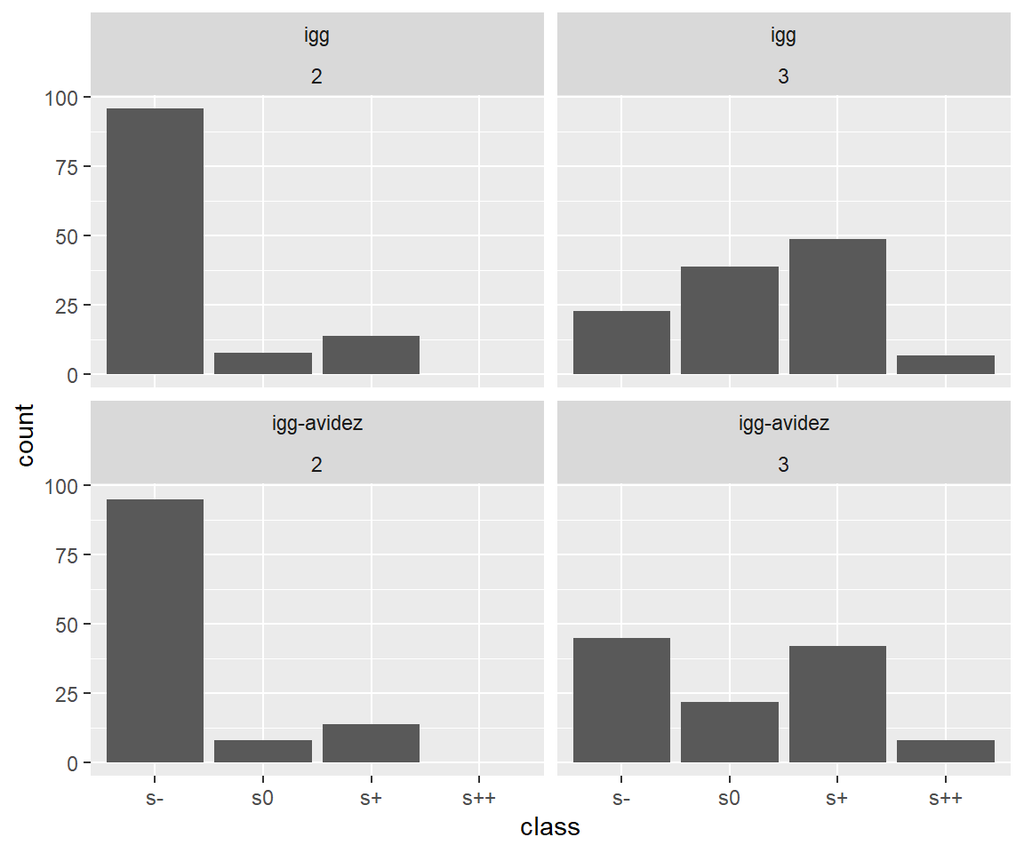

```r
data_output_04 %>%
  ggplot(aes(x = class)) +
  geom_bar() +
  facet_wrap(~experimento+component_n)
```

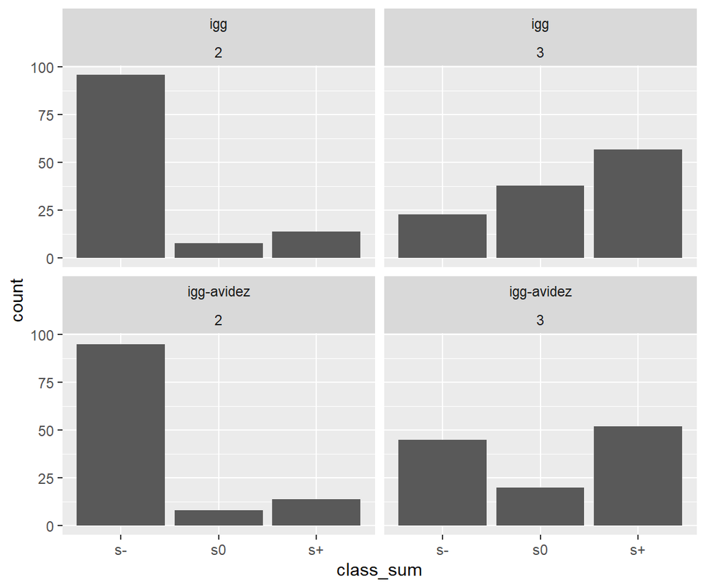

```r
data_output_04 %>%
  ggplot(aes(x = class_sum)) +
  geom_bar() +
  facet_wrap(~experimento+component_n)
```

### by classification probability

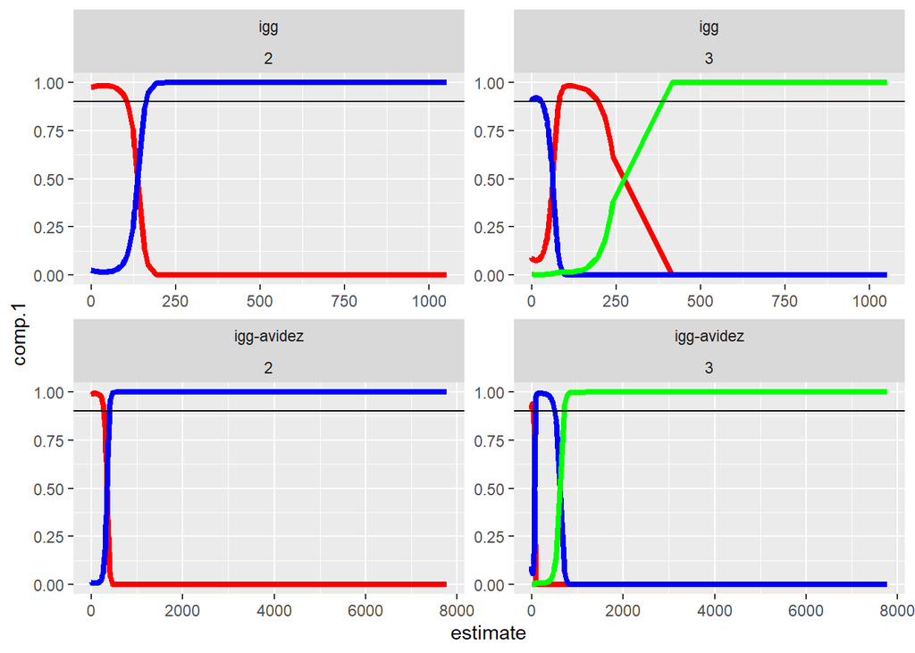

```r
data_output_04 %>%
  ggplot() +
  geom_line(aes(x = estimate,y = comp.1), colour="red", lwd = 1.5) +
  geom_line(aes(x = estimate,y = comp.2), colour="blue", lwd = 1.5) +
  geom_line(aes(x = estimate,y = comp.3), colour="green", lwd = 1.5) +
  geom_hline(yintercept = class_probability, col = "black") +
  facet_wrap(~experimento+component_n,scales = "free")
```

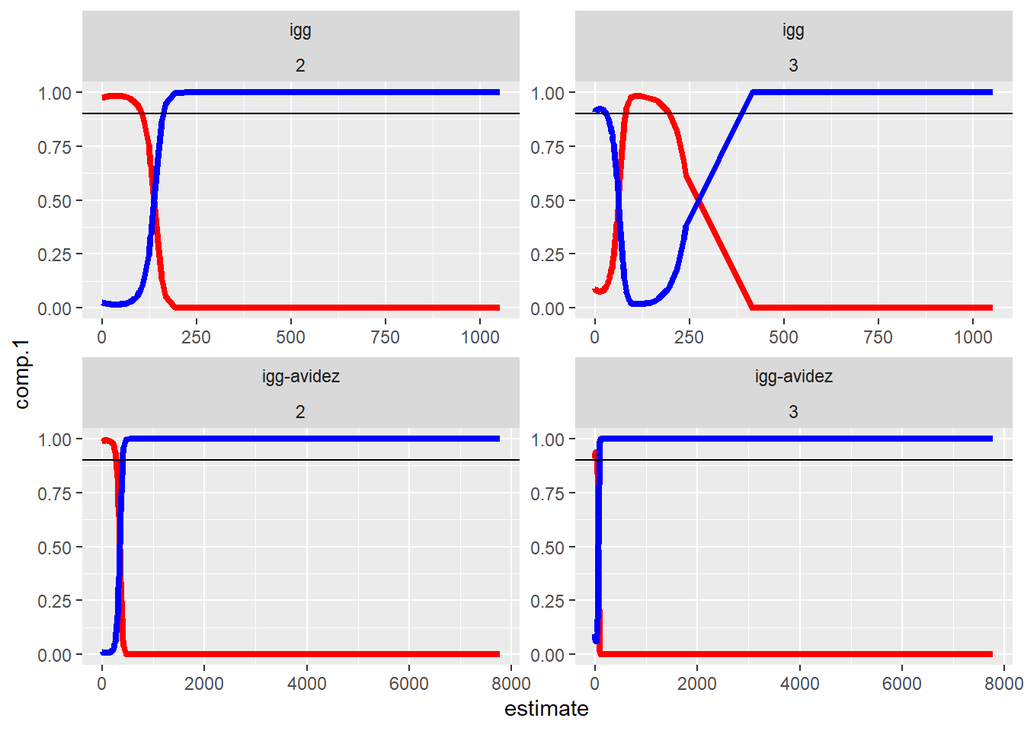

```r
data_output_04 %>%
  ggplot() +
  geom_line(aes(x = estimate,y = comp.1), colour="red", lwd = 1.5) +
  geom_line(aes(x = estimate,y = comp.23), colour="blue", lwd = 1.5) +
  geom_hline(yintercept = class_probability, col = "black") +
  facet_wrap(~experimento+component_n,scales = "free")
```

## select model

First explore equivalent class labelling

```r
data_output_04 %>%
  filter(experimento == "igg" & component_n == 2 |
           experimento == "igg-avidez" & component_n == 2) %>%
  count(experimento,class,class_sum)
```

```
## # A tibble: 6 × 4
##   experimento class class_sum     n
##   <chr>       <fct> <fct>     <int>
## 1 igg         s-    s-           96
## 2 igg         s0    s0            8
## 3 igg         s+    s+           14
## 4 igg-avidez  s-    s-           95
## 5 igg-avidez  s0    s0            8
## 6 igg-avidez  s+    s+           14
```

Then, select model by `k-component` and `k-labeling` column

```r
data_output_05 <- data_output_04 %>%
  filter(experimento == "igg" & component_n == 2 |
           experimento == "igg-avidez" & component_n == 2) %>%
  select(-class_sum)

data_output_05 %>%
  count(experimento,component_n)
```

```
## # A tibble: 2 × 3
##   experimento component_n     n
##   <chr>             <dbl> <int>
## 1 igg                   2   118
## 2 igg-avidez            2   117
```

```r
data_output_05 %>% rmarkdown::paged_table()
```

| experimento | plate | codigo | densidad_replicate | densidad_mean | densidad_sd | estimate | component_n | comp.1 | comp.2 | comp.3 | comp.23 | class | unique_id |
| --- | --- | --- | --- | --- | --- | --- | --- | --- | --- | --- | --- | --- | --- |
| igg | placa_001 | NSH-3001 | 2 | 0.70500000 | 0.01838478 | 48.89389984 | 2 | 0.98291822 | 0.01708178 | NA | 0.01708178 | s- | placa_001--NSH-3001 |
| igg | placa_001 | NSH-3002 | 2 | 1.20450000 | 0.13930004 | 883.23577457 | 2 | 0.00000000 | 1.00000000 | NA | 1.00000000 | s+ | placa_001--NSH-3002 |
| igg | placa_001 | NSH-3003 | 2 | 0.88650000 | 0.14495689 | 129.51736790 | 2 | 0.65457685 | 0.34542315 | NA | 0.34542315 | s0 | placa_001--NSH-3003 |
| igg | placa_001 | NSH-3004 | 2 | 0.32350000 | 0.00777817 | 4.96195369 | 2 | 0.97683143 | 0.02316857 | NA | 0.02316857 | s- | placa_001--NSH-3004 |
| igg | placa_001 | NSH-3005 | 2 | 0.98000000 | 0.08485281 | 217.42472141 | 2 | 0.00012842 | 0.99987158 | NA | 0.99987158 | s+ | placa_001--NSH-3005 |
| igg | placa_001 | NSH-3006 | 2 | 0.36450000 | 0.00636396 | 6.61823840 | 2 | 0.97770884 | 0.02229116 | NA | 0.02229116 | s- | placa_001--NSH-3006 |
| igg | placa_001 | NSH-3007 | 2 | 0.52600000 | 0.00424264 | 18.13343395 | 2 | 0.98193413 | 0.01806587 | NA | 0.01806587 | s- | placa_001--NSH-3007 |
| igg | placa_001 | NSH-3008 | 2 | 0.55500000 | 0.02969848 | 21.42041217 | 2 | 0.98266293 | 0.01733707 | NA | 0.01733707 | s- | placa_001--NSH-3008 |
| igg | placa_001 | NSH-3009 | 2 | 0.24350000 | 0.02474874 | 2.66226985 | 2 | 0.97547085 | 0.02452915 | NA | 0.02452915 | s- | placa_001--NSH-3009 |
| igg | placa_001 | NSH-3010 | 2 | 0.68600000 | 0.12020815 | 44.13948546 | 2 | 0.98358091 | 0.01641909 | NA | 0.01641909 | s- | placa_001--NSH-3010 |

[output cut: 225 more lines]

# outputs

```r
data_output_05 %>%
  write_rds("data/05-data-clasification-ab_units.rds")

data_output_05 %>%
  writexl::write_xlsx("data/05-data-clasification-ab_units.xlsx")
```

# open questions

- how to deal with uncertainty in the estimate and classification (which is only based on the point estimate currently)
- how to deal with missing values? current status: excluded from classification algorithm and final data output

# to do list

- clean output data table number in components
- export final table to user
- create unique with uncommon (?) hash `--`
- select one `class` column
- compare traditional vs data-base classification (new file)
- add workflow to https://app.diagrams.net/#G1WQ_PMmH3x6JMVnYcSdkagbiA_kiOyBG3

later

- replace `plot_mix_comps` with broom like function for tidy tibble model summary
- replace density plots by automatic color based plots
- remove redundant n=3 plots
- ref: https://www.hindawi.com/journals/jir/2015/738030/
- ref: https://github.com/avallecam/elixr/blob/master/00-appendix.Rmd
- replace this 05-files workflow with the most simple univariate example –> data from https://malariajournal.biomedcentral.com/articles/10.1186/s12936-018-2471-6